# Project EDA

Karan Thacker

28 August 2017

# Introdution

This is a project on doing Exploratory Data Analysis on a set of observations of white wine. **Objective** to be acheived is to get an idea about which variables are closely related to the output variable `quality` of the data set. To acheive this objective, the primary tool is the `ggplot` package to create plots including :

- scatter plots
- histograms
- box plots
- bar charts
- line graphs

The procedure implemented is as follows:

1. Examining the data structure
2. exploring single variable
3. exploring 2 variable relationship
4. exploring multi variable relationship

## Examining the data structure

below is the structure of the data frame of white wine which is named `ww` and the type of each variable is shown. Also the stats of each variable is given by the summary function

```
## 'data.frame':    4898 obs. of  13 variables:
##  $ X                   : int  1 2 3 4 5 6 7 8 9 10 ...
##  $ fixed.acidity       : num  7 6.3 8.1 7.2 7.2 8.1 6.2 7 6.3 8.1 ...
##  $ volatile.acidity    : num  0.27 0.3 0.28 0.23 0.23 0.28 0.32 0.27 0.3 0.22 ...
##  $ citric.acid         : num  0.36 0.34 0.4 0.32 0.32 0.4 0.16 0.36 0.34 0.43 ...
##  $ residual.sugar      : num  20.7 1.6 6.9 8.5 8.5 6.9 7 20.7 1.6 1.5 ...
##  $ chlorides           : num  0.045 0.049 0.05 0.058 0.058 0.05 0.045 0.045 0.049 0.044 ...
##  $ free.sulfur.dioxide : num  45 14 30 47 47 30 30 45 14 28 ...
##  $ total.sulfur.dioxide: num  170 132 97 186 186 97 136 170 132 129 ...
##  $ density             : num  1.001 0.994 0.995 0.996 0.996 ...
##  $ pH                  : num  3 3.3 3.26 3.19 3.19 3.26 3.18 3 3.3 3.22 ...
##  $ sulphates           : num  0.45 0.49 0.44 0.4 0.4 0.44 0.47 0.45 0.49 0.45 ...
##  $ alcohol             : num  8.8 9.5 10.1 9.9 9.9 10.1 9.6 8.8 9.5 11 ...
##  $ quality             : int  6 6 6 6 6 6 6 6 6 6 ...
```

```
##        X        fixed.acidity    volatile.acidity  citric.acid
##  Min.   :   1   Min.   : 3.800   Min.   :0.0800   Min.   :0.0000
##  1st Qu.:1225   1st Qu.: 6.300   1st Qu.:0.2100   1st Qu.:0.2700
##  Median :2450   Median : 6.800   Median :0.2600   Median :0.3200
##  Mean   :2450   Mean   : 6.855   Mean   :0.2782   Mean   :0.3342
##  3rd Qu.:3674   3rd Qu.: 7.300   3rd Qu.:0.3200   3rd Qu.:0.3900
##  Max.   :4898   Max.   :14.200   Max.   :1.1000   Max.   :1.6600
##  residual.sugar     chlorides       free.sulfur.dioxide
##  Min.   : 0.600   Min.   :0.00900   Min.   :  2.00
##  1st Qu.: 1.700   1st Qu.:0.03600   1st Qu.: 23.00
##  Median : 5.200   Median :0.04300   Median : 34.00
##  Mean   : 6.391   Mean   :0.04577   Mean   : 35.31
##  3rd Qu.: 9.900   3rd Qu.:0.05000   3rd Qu.: 46.00
##  Max.   :65.800   Max.   :0.34600   Max.   :289.00
##  total.sulfur.dioxide    density             pH          sulphates
##  Min.   :  9.0        Min.   :0.9871   Min.   :2.720   Min.   :0.2200
##  1st Qu.:108.0        1st Qu.:0.9917   1st Qu.:3.090   1st Qu.:0.4100
##  Median :134.0        Median :0.9937   Median :3.180   Median :0.4700
##  Mean   :138.4        Mean   :0.9940   Mean   :3.188   Mean   :0.4898
##  3rd Qu.:167.0        3rd Qu.:0.9961   3rd Qu.:3.280   3rd Qu.:0.5500
##  Max.   :440.0        Max.   :1.0390   Max.   :3.820   Max.   :1.0800
##     alcohol         quality
##  Min.   : 8.00   Min.   :3.000
##  1st Qu.: 9.50   1st Qu.:5.000
##  Median :10.40   Median :6.000
##  Mean   :10.51   Mean   :5.878
##  3rd Qu.:11.40   3rd Qu.:6.000
##  Max.   :14.20   Max.   :9.000
```

## exploring single variable

summarising the output variable quality with stats of mean median max min etc

```
##    Min. 1st Qu.  Median    Mean 3rd Qu.    Max.
##   3.000   5.000   6.000   5.878   6.000   9.000
```

```
##
##    3    4    5    6    7    8    9
##   20  163 1457 2198  880  175    5
```

we can see that **9** is the top score of `rating` variable with median score of **6**

### plotting histogram for quality

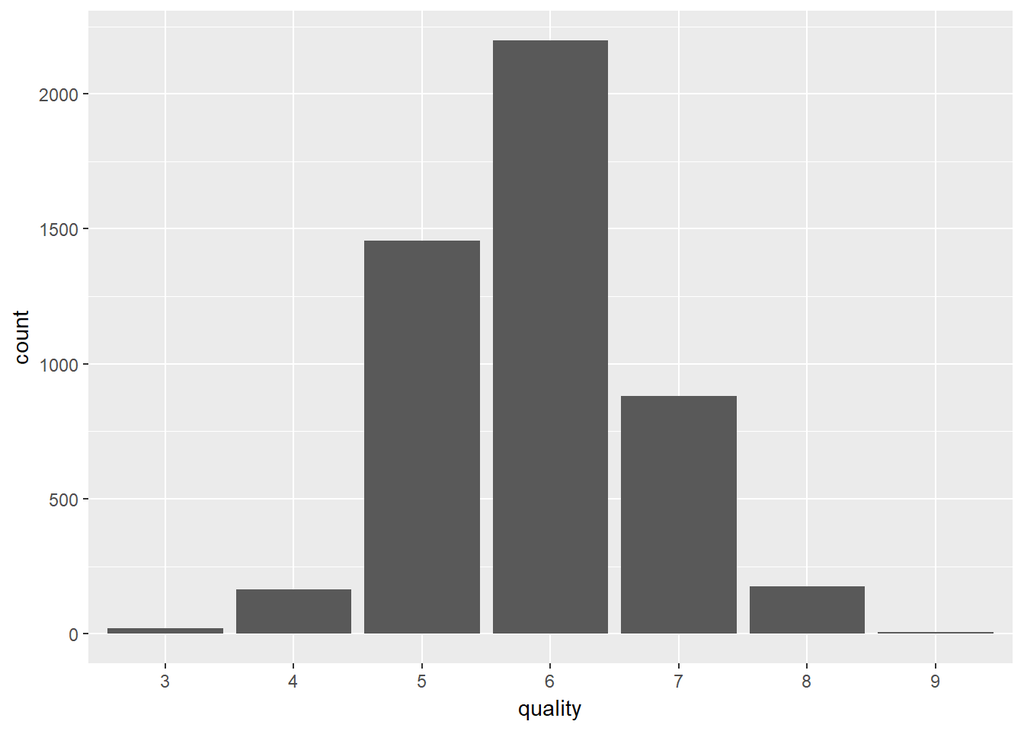

### Categorising the output variable

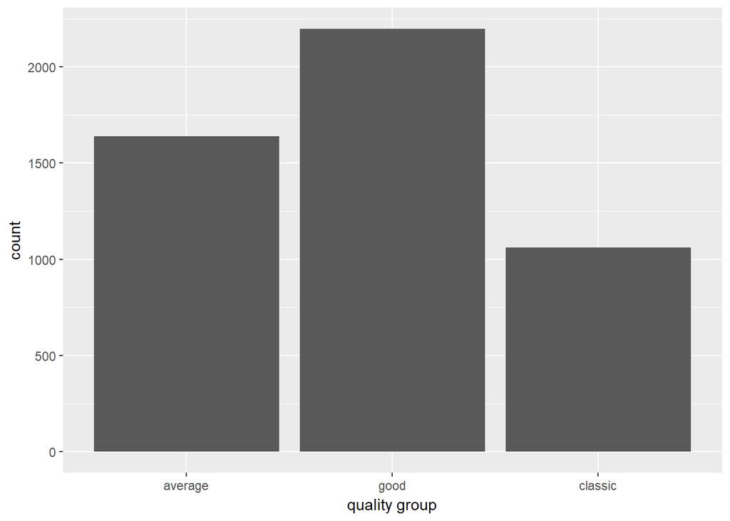

```
##
## average    good classic
##    1640    2198    1060
```

There is a new variable introduced which is `quality_G’ which is categorised into 3 groups :

1. rating (0-5) -> average
2. rating (6) -> good
3. rating (>6) -> classic

### Creating histograms for all the input variables and drawing inference

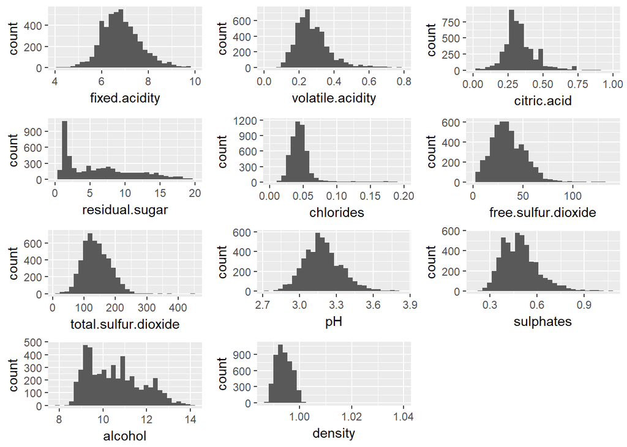

As the plot suggests for the following variables :

- fixed acidity : shows normal distribution with most of the values between 6-8 (mg / dm^3)
- volatile acidity: shows squed dist with long tail(lots of outliers)
- citric acid: shows normal curve
- residual sugar : lots of outliers and non - uniformity
- chlorides : normal curve yet lots of outliers
- free sulfur dioxide: squed graph
- sulphates : bi-modal distribution
- alcohol : spread unevenly over the whole range

### Scaling uneven graphs to log 10

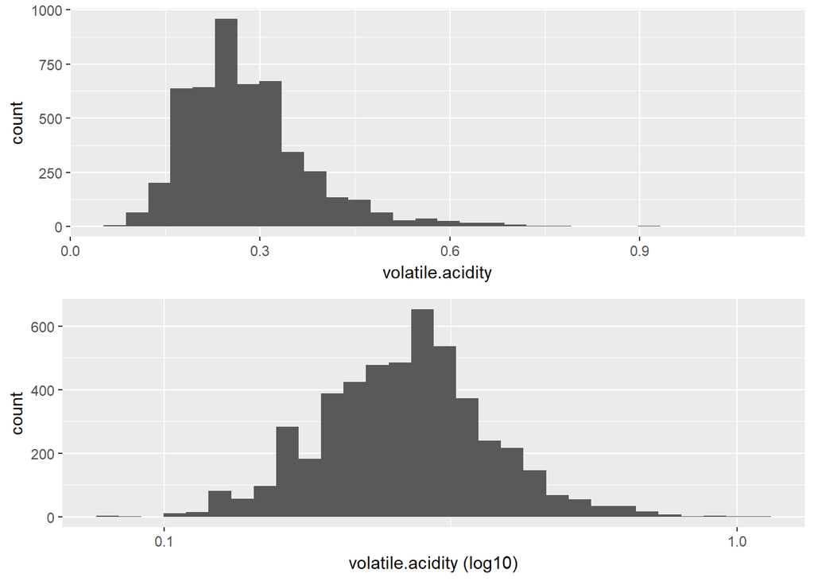

Above, Using the scale of log to the base 10 the distribution is normalised

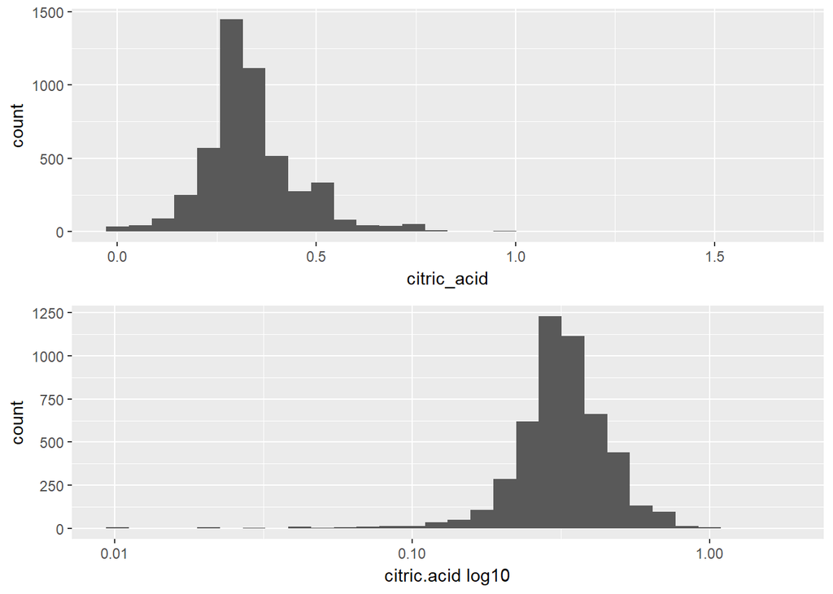

the tail got shifted from back to front end but noromalising the count histograms of variables are not able to give any insight other than the knowing that

- the range is widely spread
- there are plenty of outliers

applying log scale to the sugar residual

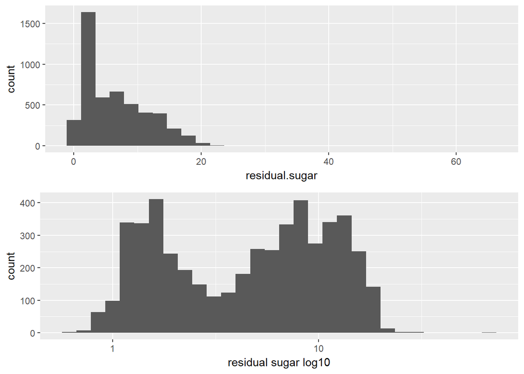

the squed histogram turns out to be bimodal on log scale

## Exploring relationship between two variables

Below is a **scatter plot matrix** to look upto for future investigations

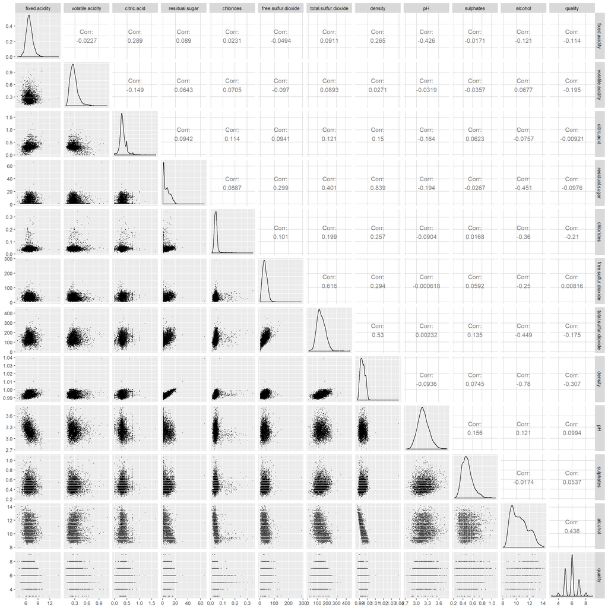

the lower half of the diagonals is made of scatter plots of variables in the index and the above is filled with correlation coefficient of person’s correlation.

### plotting boxplots for all variables with respect to Quality

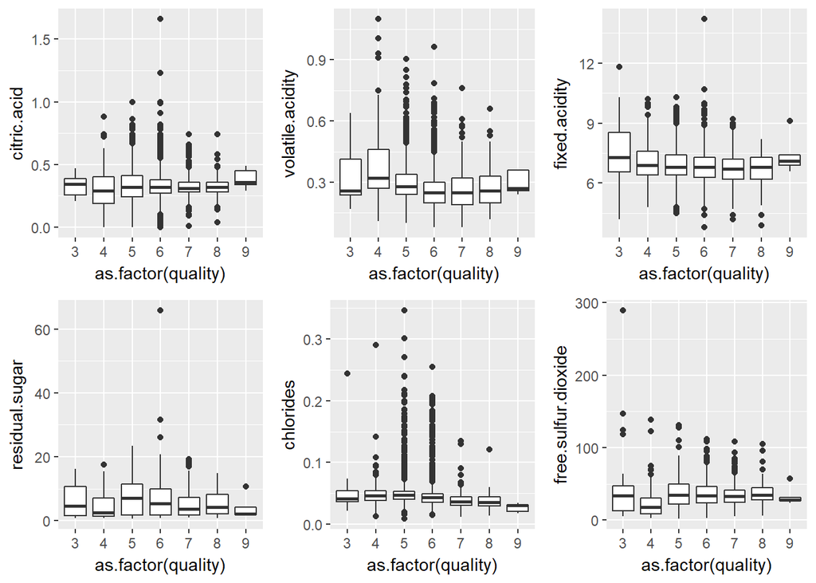

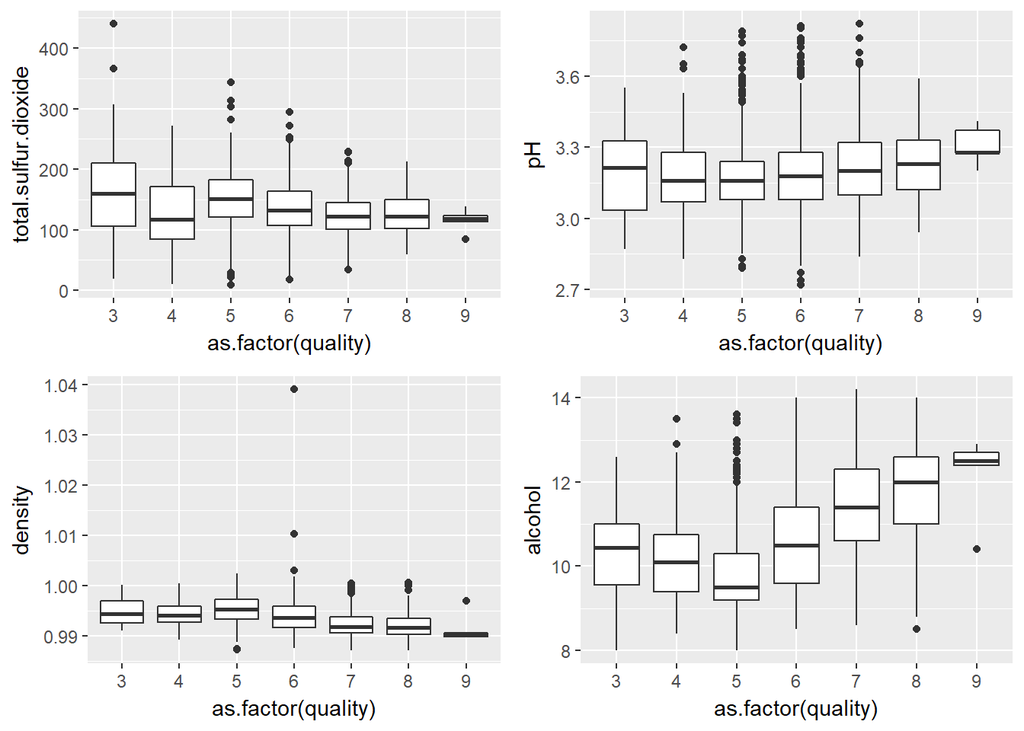

### Drawing conclusion from the box plots

- lots of outliers in the plots of citric acid, volatile acid and chlorides
- for the quality rating of 9 we can see that there is a distingushed range of quantity in all the variables. for example there is a fixed rate of sulfur dioxide for the qaulity 9 whines other than just one outlier.
- also for density lowest value is recorded against quality rating 9 with one outlier

### scatter plots between 2 variables

#### fixed acidity vs density

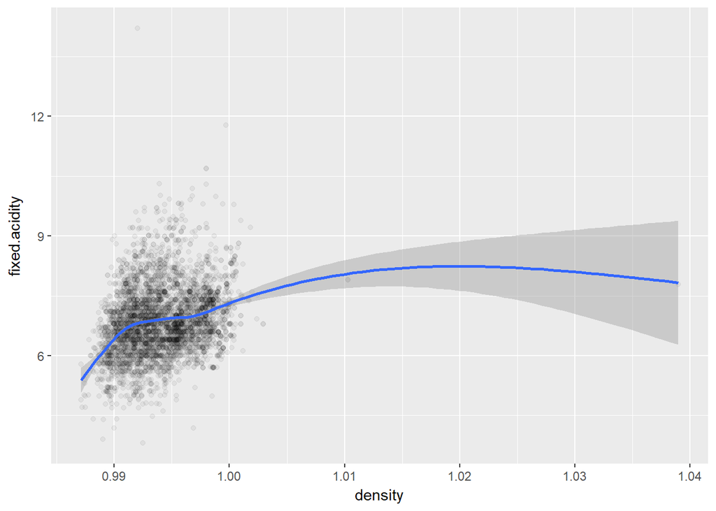

Not able to draw any inference out of it . There seems to be a positive slope bu the residual length around it is too large to be compromised. So i find a dead end to find any link between these two variables

#### total sulfur dioxide vs sulphates

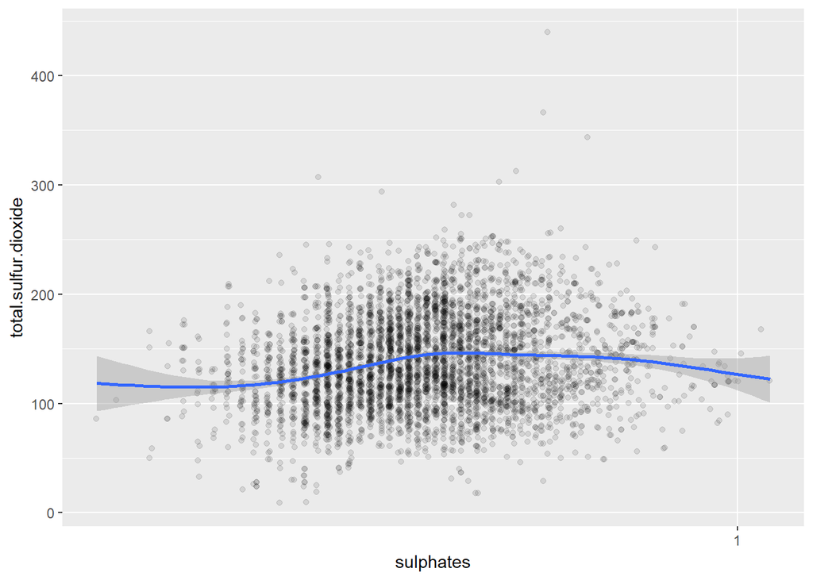

since the source of sulfur dioxide in wine is sulphate so i chose to plot them against each other. But the plot failed to establish the dependancy of sulfur dioxide on sulphates

#### Creating a new variable

```
##    Min. 1st Qu.  Median    Mean 3rd Qu.    Max.
##   4.110   6.570   7.070   7.133   7.590  14.470
```

Above, summary stats of the variable ‘total_acidity’

### plotting total_acidity vs quality

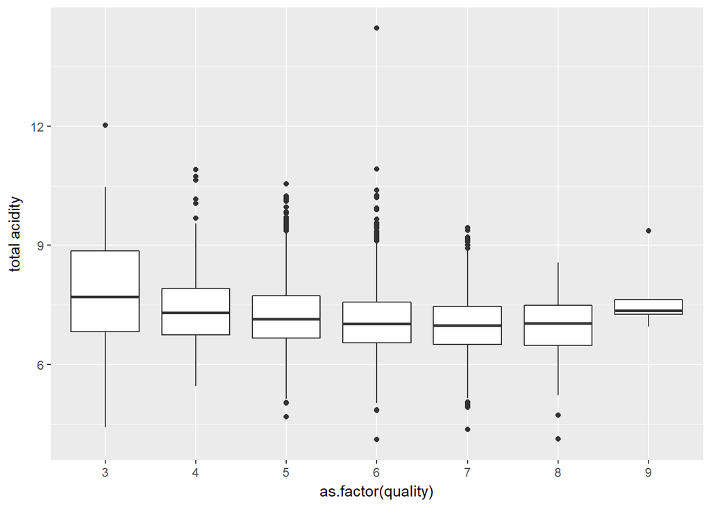

adding volatile and fixed acidity together and than ploting it against quality. we can see that average acidity is declining as we should towards better quality. Only the wines with quality rating 9 are the exception.

**There seems to be a dependency of quality on the variable density as per the boxplot lets check out the pearson’s coeffecient between them**

```
##
##  Pearson's product-moment correlation
##
## data:  density and quality
## t = -22.581, df = 4896, p-value < 2.2e-16
## alternative hypothesis: true correlation is not equal to 0
## 95 percent confidence interval:
##  -0.3322718 -0.2815385
## sample estimates:
##        cor
## -0.3071233
```

not a strong coef but shows an acceptable rate of connection between the two so lets visit the boxplot again to see if there are any trends visible

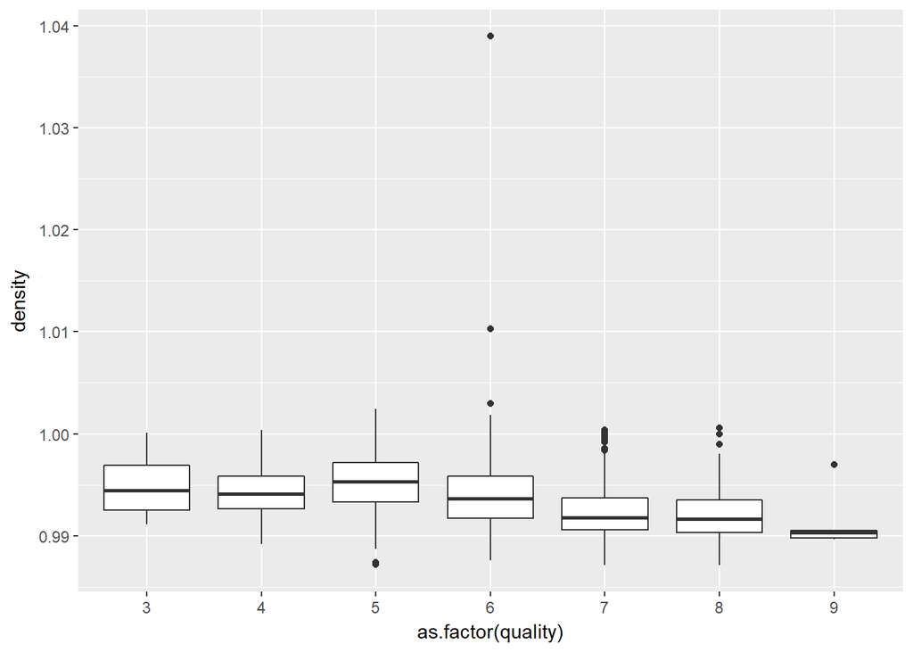

We can see a steady dip in the boxplot range after quality =5 till 9 but nothing can be clearly identified from the scatter plot but wont lose hope and give it another try by plotting mean density with the quality rating values in the form of line graph

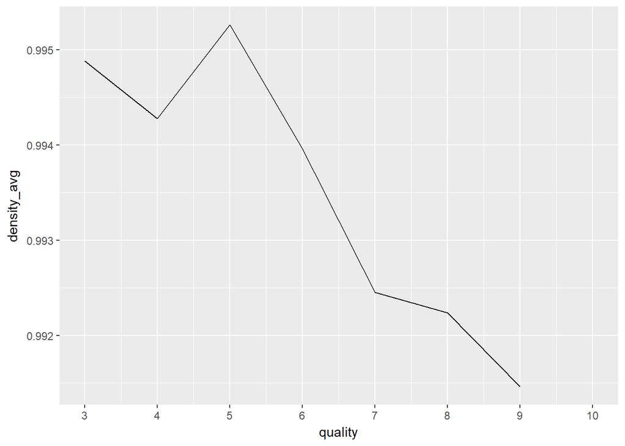

other than the starting two rating values 3 and 4 the graph shows good linear negative corelation

## summary of density averaged on the iterations of quality

```
##     quality     density_avg     density_median         n
##  Min.   :3.0   Min.   :0.9915   Min.   :0.9903   Min.   :   5.0
##  1st Qu.:4.5   1st Qu.:0.9923   1st Qu.:0.9917   1st Qu.:  91.5
##  Median :6.0   Median :0.9940   Median :0.9937   Median : 175.0
##  Mean   :6.0   Mean   :0.9935   Mean   :0.9930   Mean   : 699.7
##  3rd Qu.:7.5   3rd Qu.:0.9946   3rd Qu.:0.9943   3rd Qu.:1168.5
##  Max.   :9.0   Max.   :0.9953   Max.   :0.9953   Max.   :2198.0
```

### Calculating mean values of variables for classic quality wines

```
##          citric.acid     volatile.acidity        fixed.acidity
##           0.32605660           0.26534906           6.72514151
##       residual.sugar            chlorides  free.sulfur.dioxide
##           5.26150943           0.03816038          34.55047170
## total.sulfur.dioxide              density                   pH
##         125.24528302           0.99241198           3.21513208
##            sulphates              alcohol
##           0.50014151          11.41602201
```

### Calculating median values of variables for classic quality wines

```
##          citric.acid     volatile.acidity        fixed.acidity
##              0.31000              0.25000              6.70000
##       residual.sugar            chlorides  free.sulfur.dioxide
##              3.87500              0.03700             33.00000
## total.sulfur.dioxide              density                   pH
##            122.00000              0.99173              3.20000
##            sulphates              alcohol
##              0.48000             11.50000
```

## Multi variable exploration

### fixed acidity vs pH on quality group

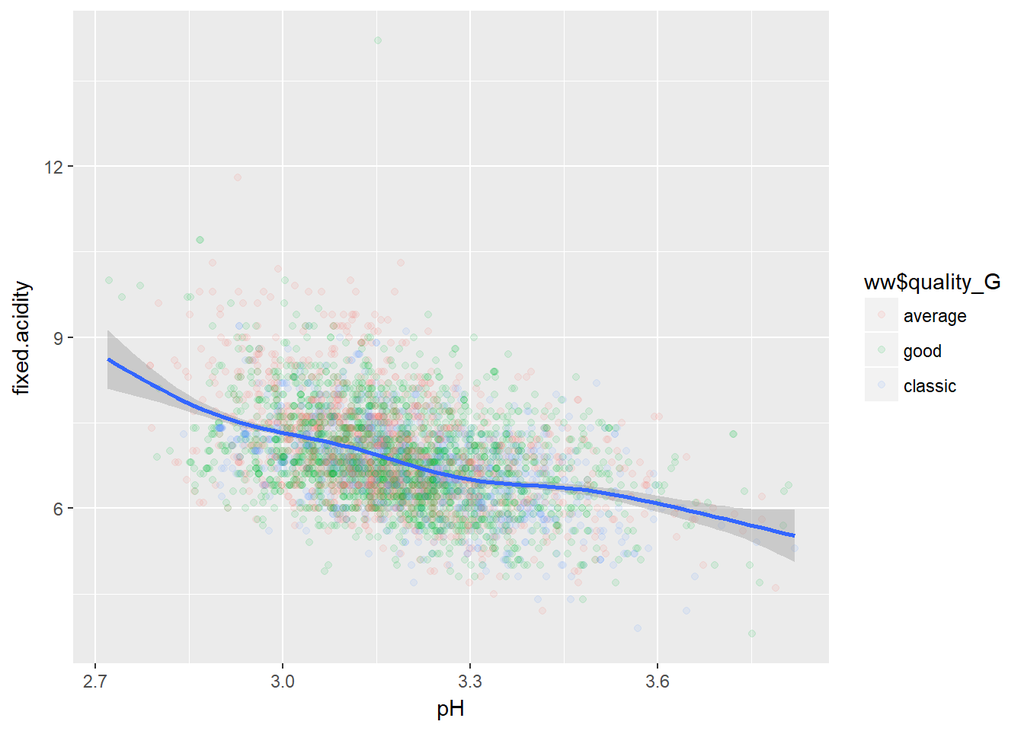

```
##
##  Pearson's product-moment correlation
##
## data:  pH and fixed.acidity
## t = -32.934, df = 4896, p-value < 2.2e-16
## alternative hypothesis: true correlation is not equal to 0
## 95 percent confidence interval:
##  -0.4485154 -0.4026542
## sample estimates:
##        cor
## -0.4258583
```

With the graph curve , we can visualise a negetive corelation between the fixed acidity and pH. scientifically also it makes good sense as more the substance acidic , less is the pH value And to back this the co relation factor is also pretty much good to establish a downward slop.

### pH vs total_acidity (coloring with alcohol and faceting with quality_G)

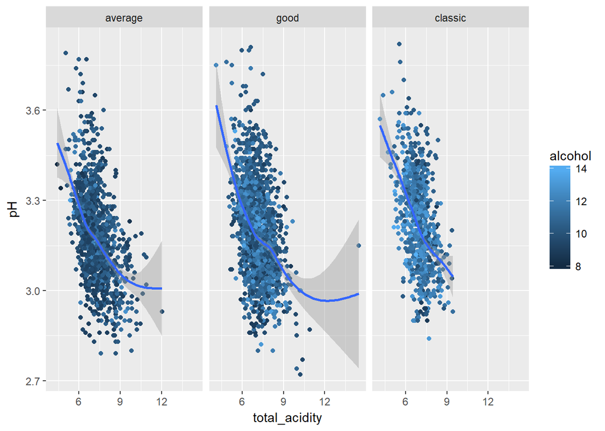

we can observe an inverse relation with the smooth line between the acidity and pH which can be understood scientifically as more the acidity lesser the pH on a scale of 1 to 14

### residual.sugar vs density (coloring with alcohol)

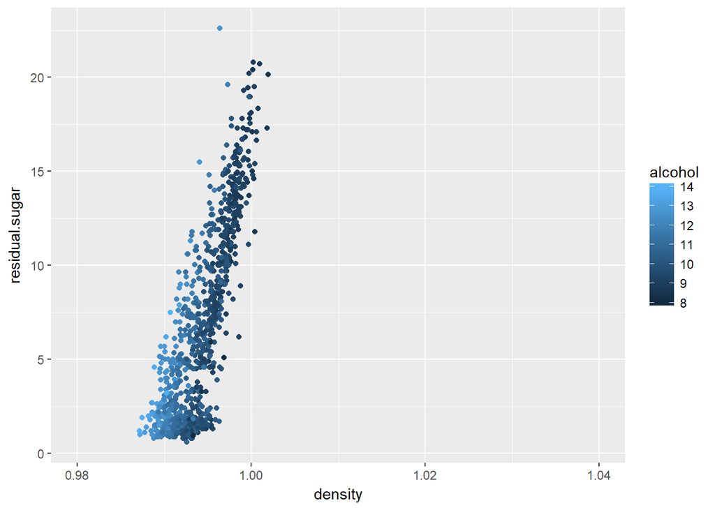

a linear relationship can be esatblished from this graph between residual sugar and density.

### alcohol vs total.sulfur.dioxide (color = as.factor(quality))

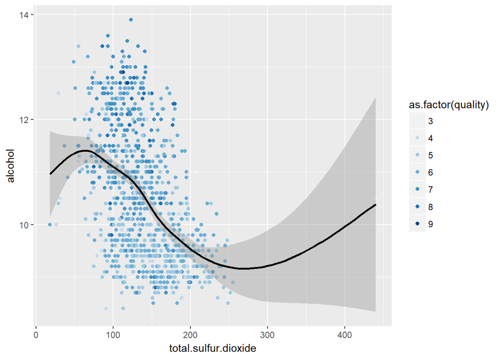

better quality wines are observed on the upper side of the graph, closer to the y axis.

# Final plots and summary

## Plot 1 : alcohol vs total.sulfur.dioxide

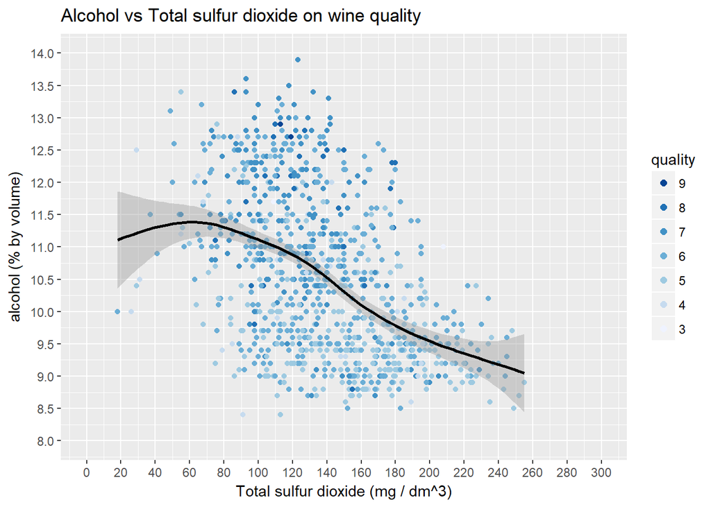

## Inference of plot 1

From this graph we can conclude that alcohol has negative correltion with sulfur dioxide and we can see that **wines of rating above 6** are mostly placed in a region of ** more alcohol % by volume and less of sulfur dioxide**

## Plot 2

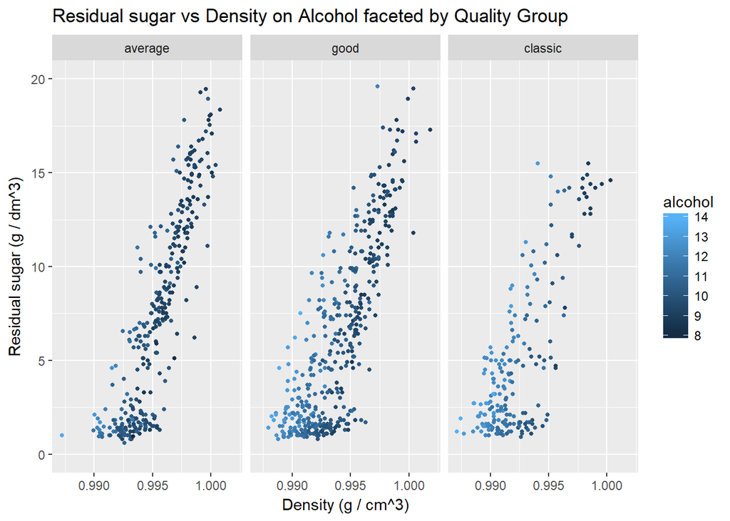

## Inference of plot 2

what we can conclude from this plot is that there is a strong linear relationship between the residual sugar and density . The important point over here is that ** at the bottom of the graph closer to 0 axis alcohol per centage is higher** which points out the fact that **lesser the sugar and density more is the alcohol %** and **more the alcohol better is the wine qaulity**. So we can indirectly link sugar and density with quality of wine on an inverse relation.

## Plot 3

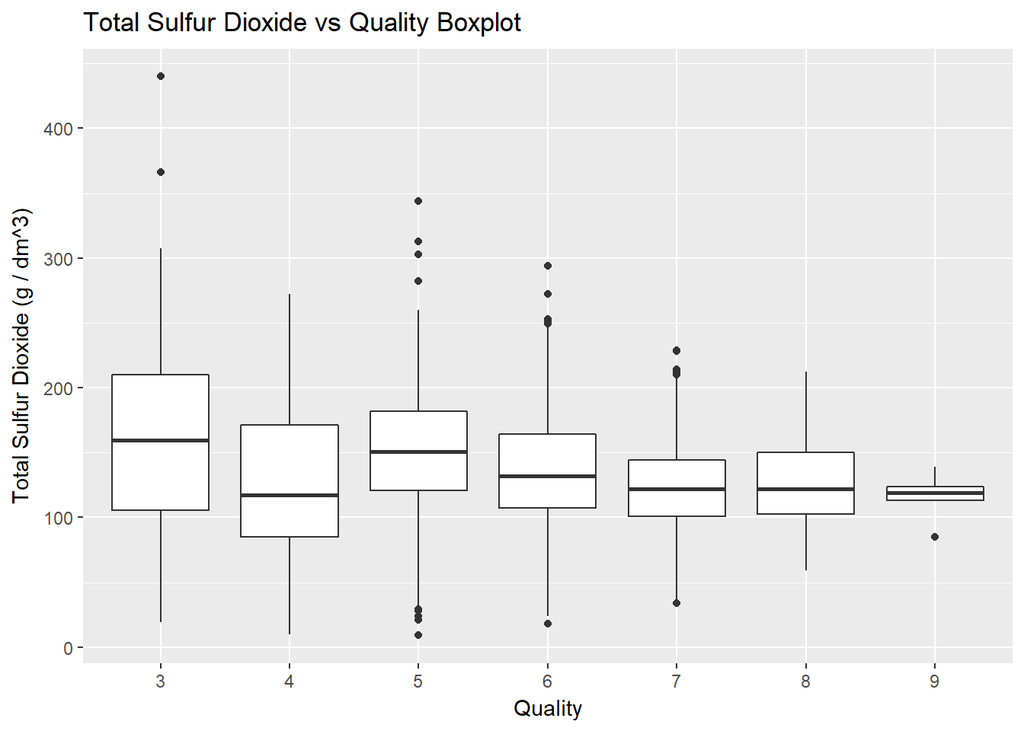

## Inference of plot 3

boxplot : we can see that as quality of wine increases the deviation of value of sulfur dioxide from the median value decreases closing on to an optimal value for quality improvement.

# Reflection

So after going through all of the EDA process i was able to connect most of the input variables to the outcome quality variable. To draw a final conclusion a higher level of alcohol % v/v , less possible density and residual sugar and an optimal value of total sulfur dioxide is the formula to create top quality wine.

Mostly the path i used to follow was strongly driven by scatter plot matrix.

The place where i got stuck was coming out with the third final plot to back a good hypothysis. The 3rd plot i came up with took me time to trace out.

Again the conclusion strongly relies on the quality ratings given by the critics which can differ as per taste or bias to a particular brand.

What future work can be done is to build a model to rate the wines from this data set and to find a configuration of elements to make top quality wine , the process should be focused on the chemistry of substances as well doing tests in the labs and finding out a perfect wine by trial and error method in labs and bruery.